# life_expectancy_gdp

```python
from matplotlib import pyplot as plt
import pandas as pd
import seaborn as sns
import numpy as np
import statsmodels.api as sm
from scipy.stats import pearsonr

df = pd.read_csv('all_data.csv')
print(df.head(10))

print(df.Country.unique())
print(df.Year.unique())
```

```
  Country  Year  Life expectancy at birth (years)           GDP
0   Chile  2000                              77.3  7.786093e+10
1   Chile  2001                              77.3  7.097992e+10
2   Chile  2002                              77.8  6.973681e+10
3   Chile  2003                              77.9  7.564346e+10
4   Chile  2004                              78.0  9.921039e+10
5   Chile  2005                              78.4  1.229650e+11
6   Chile  2006                              78.9  1.547880e+11
7   Chile  2007                              78.9  1.736060e+11
8   Chile  2008                              79.6  1.796380e+11
9   Chile  2009                              79.3  1.723890e+11
['Chile' 'China' 'Germany' 'Mexico' 'United States of America' 'Zimbabwe']
[2000 2001 2002 2003 2004 2005 2006 2007 2008 2009 2010 2011 2012 2013
 2014 2015]
```

```python
df = df.rename({"Life expectancy at birth (years)":"Life_Expectancy"}, axis = "columns")
df.head()
```

|  | Country | Year | Life_Expectancy | GDP |
| --- | --- | --- | --- | --- |
| 0 | Chile | 2000 | 77.3 | 7.786093e+10 |
| 1 | Chile | 2001 | 77.3 | 7.097992e+10 |
| 2 | Chile | 2002 | 77.8 | 6.973681e+10 |
| 3 | Chile | 2003 | 77.9 | 7.564346e+10 |
| 4 | Chile | 2004 | 78.0 | 9.921039e+10 |

```
  Country  Year  Life_Expectancy           GDP
0   Chile  2000             77.3  7.786093e+10
1   Chile  2001             77.3  7.097992e+10
2   Chile  2002             77.8  6.973681e+10
3   Chile  2003             77.9  7.564346e+10
4   Chile  2004             78.0  9.921039e+10
```

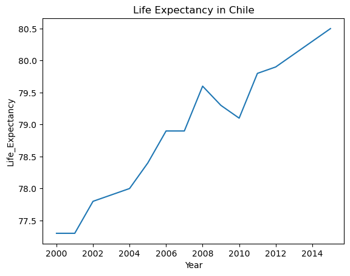

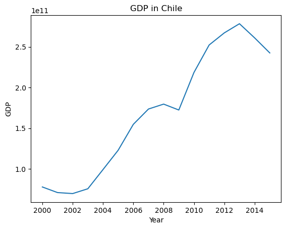

```
Intercept    7.672234e+01
GDP          1.308337e-11
dtype: float64
```

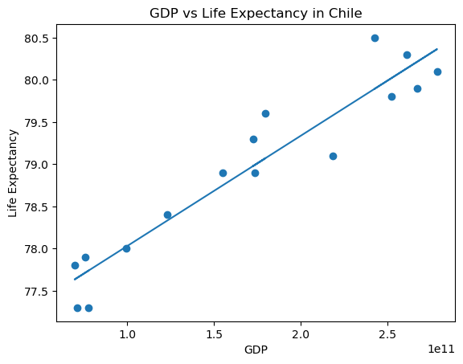

```
Correlation coefficient of GDP and life expectancy in Chile: 0.9498766659254417
```

```python
chile_data = df[df['Country'] == 'Chile']
print(chile_data.head())

sns.lineplot(x = chile_data.Year, y = chile_data.Life_Expectancy)
plt.title('Life Expectancy in Chile')
plt.show()
plt.clf()

sns.lineplot(x = chile_data.Year, y = chile_data.GDP)
plt.title('GDP in Chile')
plt.show()
plt.clf()

model = sm.OLS.from_formula('Life_Expectancy ~ GDP', data = chile_data)
results = model.fit()
print(results.params)

plt.scatter(chile_data.GDP, chile_data.Life_Expectancy)
plt.plot(chile_data.GDP, results.params[1]*chile_data.GDP + results.params[0])
plt.title('GDP vs Life Expectancy in Chile')
plt.xlabel('GDP')
plt.ylabel('Life Expectancy')
plt.show()
plt.clf()

corrcoeff_chile = np.corrcoef(chile_data.GDP, chile_data.Life_Expectancy)[0, 1]
print("Correlation coefficient of GDP and life expectancy in Chile: " + str(corrcoeff_chile))
```

- There is a strong positive correlation between GDP and life expectancy in Chile.
- There is a decline in GDP and life expectancy between 2008 and 2010.
- There is also a decline in GDP from 2013 and above.

```
   Country  Year  Life_Expectancy           GDP
16   China  2000             71.7  1.211350e+12
17   China  2001             72.2  1.339400e+12
18   China  2002             72.7  1.470550e+12
19   China  2003             73.1  1.660290e+12
20   China  2004             73.5  1.955350e+12
```

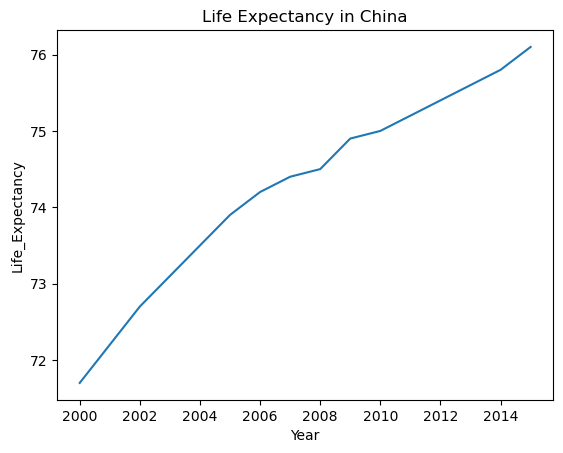

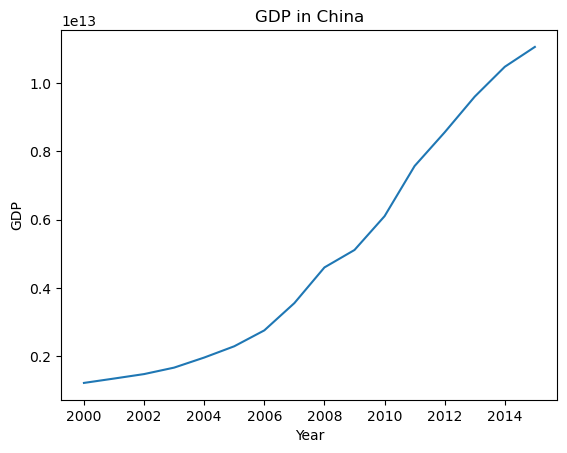

```
Intercept    7.256685e+01
GDP          3.420219e-13
dtype: float64
```

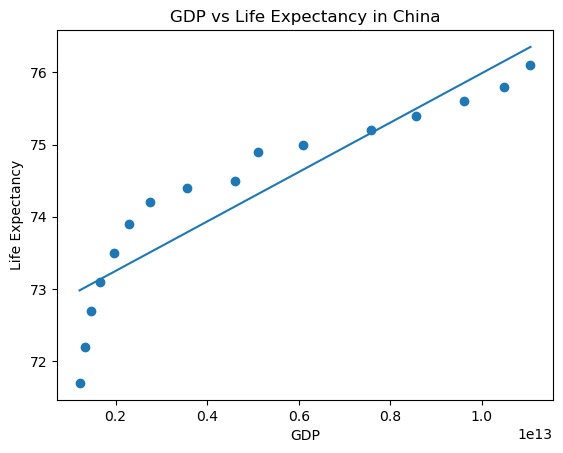

```
Correlation coefficient of GDP and life expectancy in China: 0.9085255408648356
```

```python
china_data = df[df['Country'] == 'China']
print(china_data.head())

sns.lineplot(x = china_data.Year, y = china_data.Life_Expectancy)
plt.title('Life Expectancy in China')
plt.show()
plt.clf()

sns.lineplot(x = china_data.Year, y = china_data.GDP)
plt.title('GDP in China')
plt.show()
plt.clf()

model = sm.OLS.from_formula('Life_Expectancy ~ GDP', data = china_data)
results = model.fit()
print(results.params)

plt.scatter(china_data.GDP, china_data.Life_Expectancy)
plt.plot(china_data.GDP, results.params[1]*china_data.GDP + results.params[0])
plt.title('GDP vs Life Expectancy in China')
plt.xlabel('GDP')
plt.ylabel('Life Expectancy')
plt.show()
plt.clf()

corrcoeff_china = np.corrcoef(china_data.GDP, china_data.Life_Expectancy)[0, 1]
print("Correlation coefficient of GDP and life expectancy in China: " + str(corrcoeff_china))
```

- There is a strong positive correlation between GDP and life expectancy in China.
- However there is no sign of any decline in GDP and life expectancy between 2008 and 2010 as shown in Chile maybe because Chinese economy is not affected by US financial crisis.

```
    Country  Year  Life_Expectancy           GDP
32  Germany  2000             78.0  1.949950e+12
33  Germany  2001             78.3  1.950650e+12
34  Germany  2002             78.4  2.079140e+12
35  Germany  2003             78.5  2.505730e+12
36  Germany  2004             79.1  2.819250e+12
```

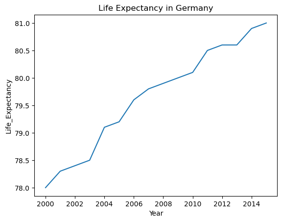

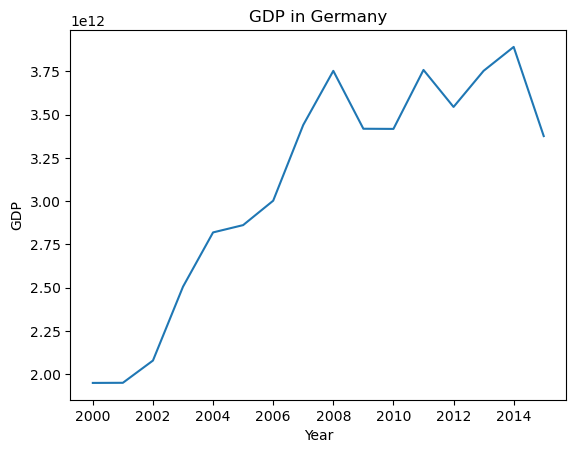

```
Intercept    7.543994e+01
GDP          1.362397e-12
dtype: float64
```

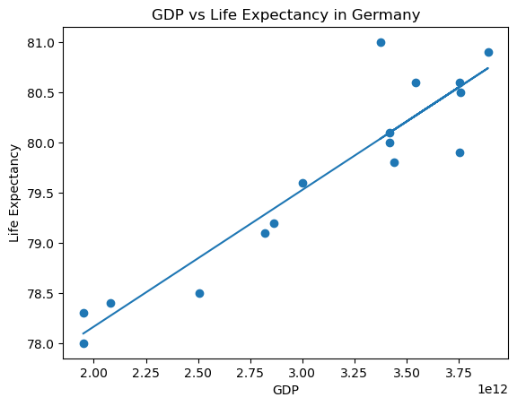

```
Correlation coefficient of GDP and life expectancy in Germany: 0.9326988982561274
```

```python
germany_data = df[df['Country'] == 'Germany']
print(germany_data.head())

sns.lineplot(x = germany_data.Year, y = germany_data.Life_Expectancy)
plt.title('Life Expectancy in Germany')
plt.show()
plt.clf()

sns.lineplot(x = germany_data.Year, y = germany_data.GDP)
plt.title('GDP in Germany')
plt.show()
plt.clf()

model = sm.OLS.from_formula('Life_Expectancy ~ GDP', data = germany_data)
results = model.fit()
print(results.params)

plt.scatter(germany_data.GDP, germany_data.Life_Expectancy)
plt.plot(germany_data.GDP, results.params[1]*germany_data.GDP + results.params[0])
plt.title('GDP vs Life Expectancy in Germany')
plt.xlabel('GDP')
plt.ylabel('Life Expectancy')
plt.show()
plt.clf()

corrcoeff_germany = np.corrcoef(germany_data.GDP, germany_data.Life_Expectancy)[0, 1]
print("Correlation coefficient of GDP and life expectancy in Germany: " + str(corrcoeff_germany))
```

```
   Country  Year  Life_Expectancy           GDP
48  Mexico  2000             74.8  6.836480e+11
49  Mexico  2001             75.0  7.247040e+11
50  Mexico  2002             75.0  7.415600e+11
51  Mexico  2003             75.0  7.132840e+11
52  Mexico  2004             75.4  7.702680e+11
```

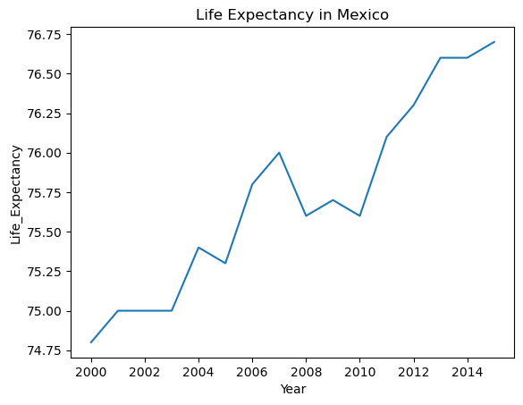

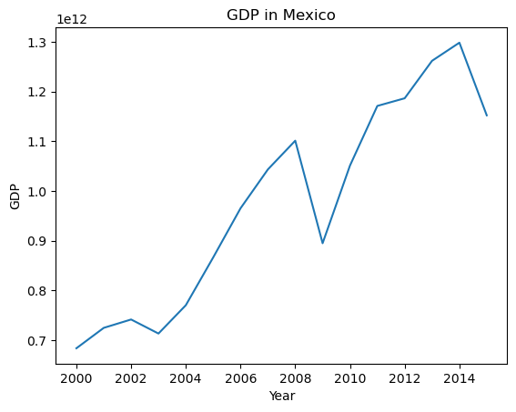

```
Intercept    7.302091e+01
GDP          2.762337e-12
dtype: float64
```

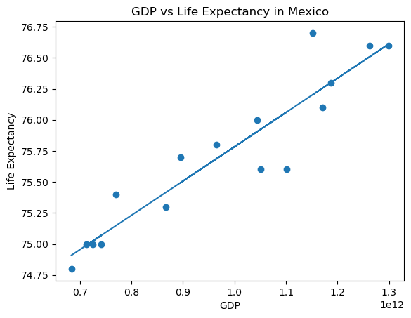

```
Correlation coefficient of GDP and life expectancy in Germany: 0.9322377167847082
```

```python
mexico_data = df[df['Country'] == 'Mexico']
print(mexico_data.head())

sns.lineplot(x = mexico_data.Year, y = mexico_data.Life_Expectancy)
plt.title('Life Expectancy in Mexico')
plt.show()
plt.clf()

sns.lineplot(x = mexico_data.Year, y = mexico_data.GDP)
plt.title('GDP in Mexico')
plt.show()
plt.clf()

model = sm.OLS.from_formula('Life_Expectancy ~ GDP', data = mexico_data)
results = model.fit()
print(results.params)

plt.scatter(mexico_data.GDP, mexico_data.Life_Expectancy)
plt.plot(mexico_data.GDP, results.params[1]*mexico_data.GDP + results.params[0])
plt.title('GDP vs Life Expectancy in Mexico')
plt.xlabel('GDP')
plt.ylabel('Life Expectancy')
plt.show()
plt.clf()

corrcoeff_mexico = np.corrcoef(mexico_data.GDP, mexico_data.Life_Expectancy)[0, 1]
print("Correlation coefficient of GDP and life expectancy in Germany: " + str(corrcoeff_mexico))
```

```
                     Country  Year  Life_Expectancy           GDP
64  United States of America  2000             76.8  1.030000e+13
65  United States of America  2001             76.9  1.060000e+13
66  United States of America  2002             77.0  1.100000e+13
67  United States of America  2003             77.2  1.150000e+13
68  United States of America  2004             77.5  1.230000e+13
```

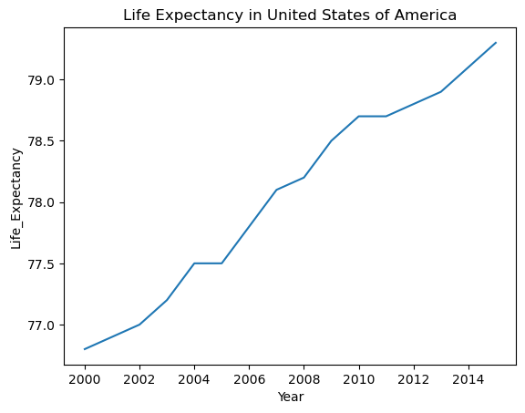

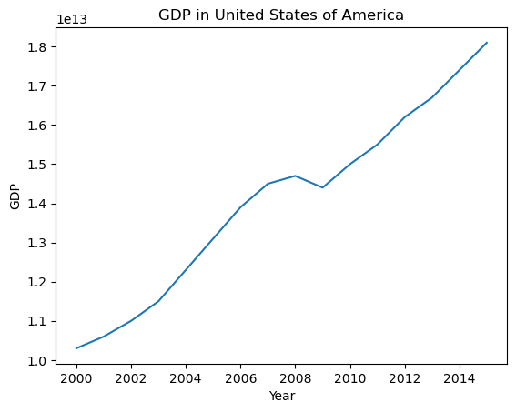

```
Intercept    7.333357e+01
GDP          3.359806e-13
dtype: float64
```

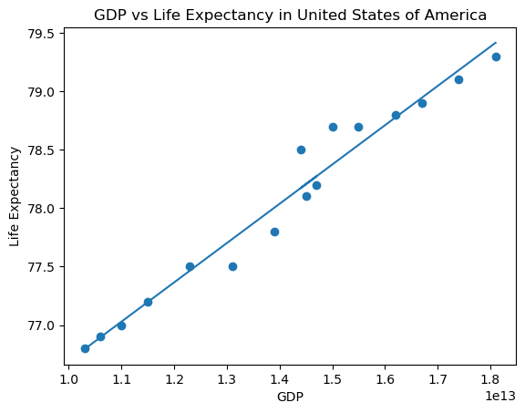

```
Correlation coefficient of GDP and life expectancy in United States of America: 0.9817092382430256
```

```python
usa_data = df[df['Country'] == 'United States of America']
print(usa_data.head())

sns.lineplot(x = usa_data.Year, y = usa_data.Life_Expectancy)
plt.title('Life Expectancy in United States of America')
plt.show()
plt.clf()

sns.lineplot(x = usa_data.Year, y = usa_data.GDP)
plt.title('GDP in United States of America')
plt.show()
plt.clf()

model = sm.OLS.from_formula('Life_Expectancy ~ GDP', data = usa_data)
results = model.fit()
print(results.params)

plt.scatter(usa_data.GDP, usa_data.Life_Expectancy)
plt.plot(usa_data.GDP, results.params[1]*usa_data.GDP + results.params[0])
plt.title('GDP vs Life Expectancy in United States of America')
plt.xlabel('GDP')
plt.ylabel('Life Expectancy')
plt.show()
plt.clf()

corrcoeff_usa = np.corrcoef(usa_data.GDP, usa_data.Life_Expectancy)[0, 1]
print("Correlation coefficient of GDP and life expectancy in United States of America: " + str(corrcoeff_usa))
```

```
     Country  Year  Life_Expectancy           GDP
80  Zimbabwe  2000             46.0  6.689958e+09
81  Zimbabwe  2001             45.3  6.777385e+09
82  Zimbabwe  2002             44.8  6.342116e+09
83  Zimbabwe  2003             44.5  5.727592e+09
84  Zimbabwe  2004             44.3  5.805598e+09
```

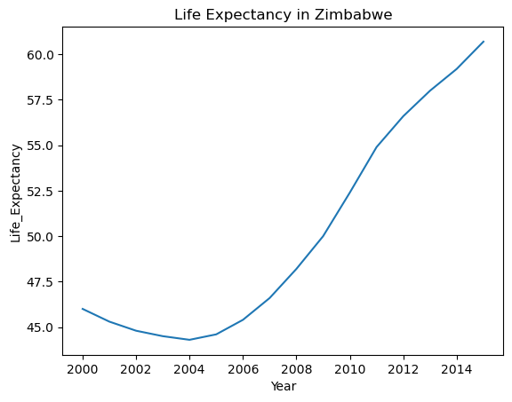

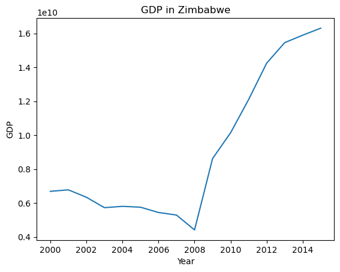

```
Intercept    3.799250e+01
GDP          1.335299e-09
dtype: float64
```

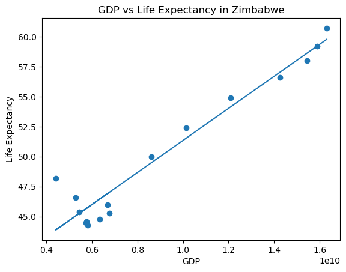

```
Correlation coefficient is 0.9661998955858779
```

```python
zimbabwe_data = df[df['Country'] == 'Zimbabwe']
print(zimbabwe_data.head())

sns.lineplot(x = zimbabwe_data.Year, y = zimbabwe_data.Life_Expectancy)
plt.title('Life Expectancy in Zimbabwe')
plt.show()
plt.clf()

sns.lineplot(x = zimbabwe_data.Year, y = zimbabwe_data.GDP)
plt.title('GDP in Zimbabwe')
plt.show()
plt.clf()

model = sm.OLS.from_formula('Life_Expectancy ~ GDP', data = zimbabwe_data)
results = model.fit()
print(results.params)

plt.scatter(zimbabwe_data.GDP, zimbabwe_data.Life_Expectancy)
plt.plot(zimbabwe_data.GDP, results.params[1]*zimbabwe_data.GDP + results.params[0])
plt.title('GDP vs Life Expectancy in Zimbabwe')
plt.xlabel('GDP')
plt.ylabel('Life Expectancy')
plt.show()
plt.clf()

corrcoeff_zimbabwe = np.corrcoef(zimbabwe_data.GDP, zimbabwe_data.Life_Expectancy)[0, 1]
print("Correlation coefficient is " + str(corrcoeff_zimbabwe))
```

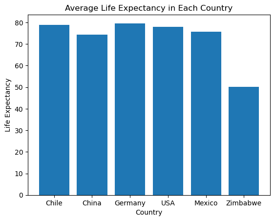

```python
# Calculate average life expectancy for each country and plot it on the bar
chile_life = int(np.sum(chile_data.Life_Expectancy))/len(chile_data.Year)
china_life = int(np.sum(china_data.Life_Expectancy))/len(china_data.Year)
germany_life = int(np.sum(germany_data.Life_Expectancy))/len(germany_data.Year)
usa_life = int(np.sum(usa_data.Life_Expectancy))/len(usa_data.Year)
mexico_life = int(np.sum(mexico_data.Life_Expectancy))/len(mexico_data.Year)
zimbabwe_life = int(np.sum(zimbabwe_data.Life_Expectancy))/len(zimbabwe_data.Year)

country = ['Chile', 'China', 'Germany', 'USA', 'Mexico', 'Zimbabwe']
life = [chile_life, china_life, germany_life, usa_life, mexico_life, zimbabwe_life]

plt.bar(country, life)
plt.title("Average Life Expectancy in Each Country")
plt.xlabel("Country")
plt.ylabel("Life Expectancy")
plt.show()
plt.clf()
```

- It is observed that all countries have similar life expectancy except Zimbabwe.

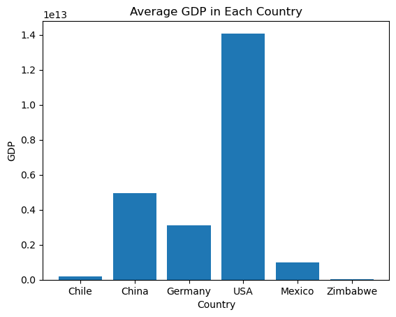

```python
# Calculate average GDP for each country and plot it in a bar
chile_gdp = int(np.sum(chile_data.GDP))/len(chile_data.Year)
china_gdp = int(np.sum(china_data.GDP))/len(china_data.Year)
germany_gdp = int(np.sum(germany_data.GDP))/len(germany_data.Year)
usa_gdp = int(np.sum(usa_data.GDP))/len(usa_data.Year)
mexico_gdp = int(np.sum(mexico_data.GDP))/len(mexico_data.Year)
zimbabwe_gdp = int(np.sum(zimbabwe_data.GDP))/len(zimbabwe_data.Year)

gdp = [chile_gdp, china_gdp, germany_gdp, usa_gdp, mexico_gdp, zimbabwe_gdp]

plt.bar(country, gdp)
plt.title("Average GDP in Each Country")
plt.xlabel("Country")
plt.ylabel("GDP")
plt.show()
plt.clf()
```

- USA has the highest GDP meanwhile Chile and Zimbabwe have the lowest GDP

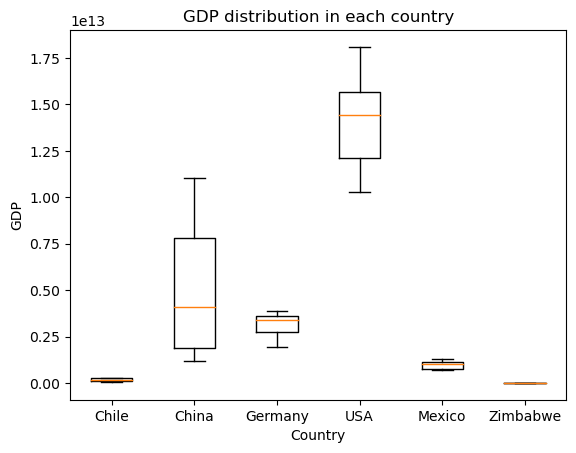

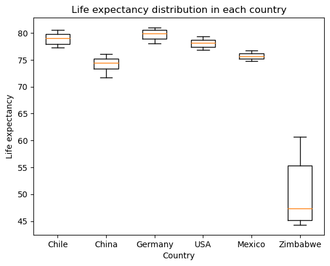

```python
# Create box plots to compare GDP and life expectancy of each country
gdp_box = [chile_data.GDP, china_data.GDP, germany_data.GDP, usa_data.GDP, mexico_data.GDP, zimbabwe_data.GDP]

plt.boxplot(gdp_box)
plt.title("GDP distribution in each country")
plt.xlabel("Country")
plt.ylabel("GDP")
plt.xticks([1, 2, 3, 4, 5, 6], country)
plt.show()
plt.clf()

life_box = [chile_data.Life_Expectancy, china_data.Life_Expectancy, germany_data.Life_Expectancy, usa_data.Life_Expectancy, mexico_data.Life_Expectancy, zimbabwe_data.Life_Expectancy]

plt.boxplot(life_box)
plt.title("Life expectancy distribution in each country")
plt.xlabel("Country")
plt.ylabel("Life expectancy")
plt.xticks([1, 2, 3, 4, 5, 6], country)
plt.show()
plt.clf()
```

- USA and China have the highest range of GDP compared to other countries. Chile, Mexico and Zimbabwe are countries with the lowest median and range of GDP.
- Median life expectancy of Zimbabwe is very low compared to other countries.

**Conclusion**

- All countries shown positive growth of life expectancy
- Zimbabwe has shown a decline in life expectancy between 2000 to 2004 which contributes to low average rate of life expectancy. However the life expectancy continues to grow after 2004.